# Assignment #5

Colleen Minnihan

```r
library(countrycode)
library(tidyverse)
library(sf)
library(rnaturalearth)
library(rnaturalearthdata)
library(rgeos)
```

[Link to my github repo for this project](https://github.com/neelloc28/AdvancedDataSci-hw5)

```r
#finding coordinates for every country in the world dataset
world <- ne_countries(scale = "medium", returnclass = "sf")
coordinates <- cbind(world, st_coordinates(st_centroid(world$geometry)))
coordinates <-
  coordinates %>%
  select(name,sovereignt, type, X,Y)
```

## Exercises:

##### Question 1: Convert the name of a country of choice into five different languages of your choice. Use the world dataset and use countryname. You can also use ‘codelist’ to look at different destinations. (Remove eval=FALSE)

```r
world <- ne_countries(scale = "medium", returnclass = "sf")

question1 <-
  world %>%
  filter(name == "Puerto Rico")

#Repeat the code down below for 4 other languages.
countryname(question1$name, "cldr.name.bn") #Bangla
```

```
## [1] "প\u09c1য\u09bc\u09c7র\u09cdত\u09cb র\u09bfক\u09cb"
```

```r
countryname(question1$name, "cldr.name.es") #Spanish
```

```
## [1] "Puerto Rico"
```

```r
countryname(question1$name, "cldr.name.ko") #Korean
```

```
## [1] "푸에르토리코"
```

```r
countryname(question1$name, "cldr.name.ja") #Japanese
```

```
## [1] "プエルトリコ"
```

```r
countryname(question1$name, "cldr.name.he") #Hebrew
```

```
## [1] "פוארטו ריקו"
```

##### Question 2: Find the ‘region’ name and code for the top 30 countries. Use ‘countrycode’ for this.

```r
#remove eval=FALSE before running
question2 <-
  world %>%
  head(30)

countrycode(question2$name, origin = 'country.name', destination = 'region') #region name
```

```
##  [1] "Latin America & Caribbean"  "South Asia"
##  [3] "Sub-Saharan Africa"         "Latin America & Caribbean"
##  [5] "Europe & Central Asia"      "Europe & Central Asia"
##  [7] "Europe & Central Asia"      "Middle East & North Africa"
##  [9] "Latin America & Caribbean"  "Europe & Central Asia"
## [11] "East Asia & Pacific"        NA
## [13] NA                           NA
## [15] "Latin America & Caribbean"  "East Asia & Pacific"
## [17] "Europe & Central Asia"      "Europe & Central Asia"
## [19] "Sub-Saharan Africa"         "Europe & Central Asia"
## [21] "Sub-Saharan Africa"         "Sub-Saharan Africa"
## [23] "South Asia"                 "Europe & Central Asia"
## [25] "Middle East & North Africa" "Latin America & Caribbean"
## [27] "Europe & Central Asia"      "Latin America & Caribbean"
## [29] "Europe & Central Asia"      "Latin America & Caribbean"
```

```r
countrycode(question2$name, origin = 'country.name', destination = 'iso3c') #code
```

```
##  [1] "ABW" "AFG" "AGO" "AIA" "ALB" "ALA" "AND" "ARE" "ARG" "ARM" "ASM" "ATA"
## [13] NA    NA    "ATG" "AUS" "AUT" "AZE" "BDI" "BEL" "BEN" "BFA" "BGD" "BGR"
## [25] "BHR" "BHS" "BIH" "BLM" "BLR" "BLZ"
```

##### Question 3: Use the guess_field() function to find the closest match of the origin of the adm0_a3 column in the world dataset.

```r
guess_field(world$adm0_a3)
```

|  | code | percent_of_unique_matched |
| --- | --- | --- |
| iso3c | iso3c | 95.85062 |
| genc3c | genc3c | 95.43568 |
| wb | wb | 87.96680 |
| wb_api3c | wb_api3c | 87.96680 |

##### Question 4: Draw a map with 5 countries with different labels using geom_sf, geom_text and countryname (you have complete freedom over what countries you want to do)

```r
coordinates <- cbind(world, st_coordinates(st_centroid(world$geometry)))
```

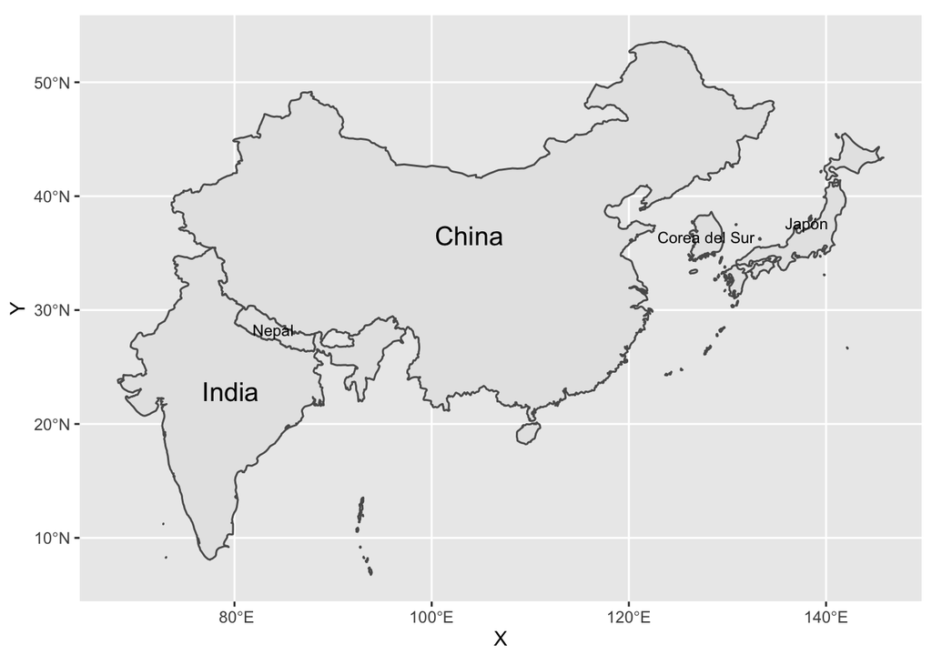

```r
coordinates <-
  coordinates %>%
  select(name,sovereignt, type, X,Y)

SouthKorea <-
  coordinates[world$name == 'Korea',] %>%
  mutate(label = countryname(name, destination = 'cldr.name.es'))

China <-
  coordinates[world$name == 'China',] %>%
  mutate(label = countryname(name, destination = 'cldr.name.es'))

Japan <-
  coordinates[world$name == 'Japan',] %>%
  mutate(label = countryname(name, destination = 'cldr.name.es'))

Japan <-
  coordinates[world$name == 'Japan',] %>%
  mutate(label = countryname(name, destination = 'cldr.name.es'))

India <-
  coordinates[world$name == 'India',] %>%
  mutate(label = countryname(name, destination = 'cldr.name.es'))

Nepal <-
  coordinates[world$name == 'Nepal',] %>%
  mutate(label = countryname(name, destination = 'cldr.name.es'))


ggplot() +
  geom_sf(data = SouthKorea) +
  geom_sf(data = Japan) +
  geom_sf(data = China) +
  geom_sf(data = India) +
  geom_sf(data = Nepal) +
  geom_text(data=SouthKorea ,aes(X, Y, label=label), size=3) +
  geom_text(data=Japan ,aes(X, Y, label=label), size=3) +
  geom_text(data=China ,aes(X, Y, label=label), size=5) +
  geom_text(data=India ,aes(X, Y, label=label), size=5) +
  geom_text(data=Nepal ,aes(X, Y, label=label), size=3)
```

##### Question 5: Draw a map that has each country named after the continent it belongs to and colored by their continent. Make sure your map looks like an actual map (not grids, not axis, add a title, a caption, etc.)

```r
continents <-
  mutate(coordinates) %>%
  mutate(continent = countrycode(sovereignt, origin = 'country.name', destination = 'continent'))
```

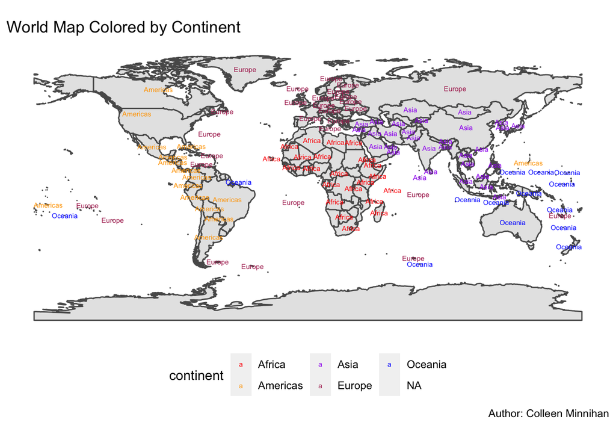

```r
#with colored text
ggplot(data = world) +
    geom_sf() +
    geom_text(data=continents ,aes(X, Y, label=continent, color = continent), check_overlap = TRUE, size=2) +
    labs(x = NULL,
         y = NULL)+
    theme(panel.background = element_blank()) +
  scale_color_manual(values=c("red", "orange", "purple", "maroon", "blue")) +
  ggtitle("World Map Colored by Continent") +
  labs(Continent = "hi", caption = "Author: Colleen Minnihan") +
  theme(legend.position = "bottom")
```

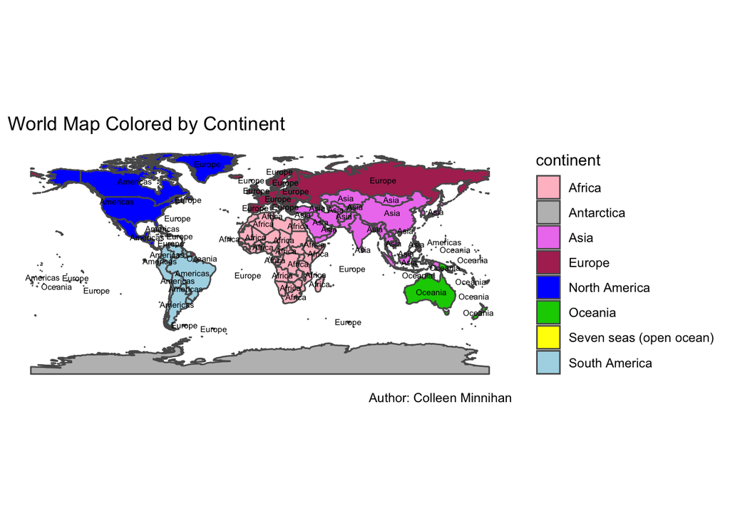

```r
#with colored continents
ggplot(data = world) +
    geom_sf(mapping = aes(fill = continent)) +
    geom_text(data=continents ,aes(X, Y, label=continent), check_overlap = TRUE, size=2) +
    labs(x = NULL,
         y = NULL)+
    theme(panel.background = element_blank()) +
  scale_fill_manual(values=c("pink", "grey", "violet", "maroon", "blue", "green3", "yellow", "lightblue")) +
  ggtitle("World Map Colored by Continent") +
  labs(color = "Continent", caption = "Author: Colleen Minnihan")
```